# HW4

Daniil Rodionov, Hugo Aubert

2024-11-09

```r
rm(list = ls())
```

# Intro

```r
load("C:/DS/Spatial_statistics/data/shrimpsfull.RData")
load("C:/DS/Spatial_statistics/data/AllGrids.RData")
```

Year 1997 & 2006

```r
shrimpsdata97 <- shrimpsdata %>%
  filter(ANNO == 1997)

shrimpsdata06 <- shrimpsdata %>%
  filter(ANNO == 2006)

shrimpsdataframe06 <- data.frame(X = shrimpsdata06$X, Y =shrimpsdata06$Y, tot = (shrimpsdata06$tot + 1), bat = shrimpsdata06$bat, tempmax3p = shrimpsdata06$temp.maxq3p, temp.maxq1 = shrimpsdata06$temp.maxq1, temp.minq4p = shrimpsdata06$temp.minq4p, temp.maxq3p = shrimpsdata06$temp.maxq3p, salinity.maxq3p = shrimpsdata06$salinity.maxq3p, salinity.maxq3 = shrimpsdata06$salinity.maxq3)

shrimpsdataframe97 <- data.frame(X = shrimpsdata97$X, Y =shrimpsdata97$Y, tot = (shrimpsdata97$tot + 1), bat = shrimpsdata97$bat, tempmax3p = shrimpsdata97$temp.maxq3p, temp.maxq1 = shrimpsdata97$temp.maxq1 , temp.minq4p = shrimpsdata97$temp.minq4p , temp.maxq3p = shrimpsdata97$temp.maxq3p , salinity.maxq3p = shrimpsdata97$salinity.maxq3p , salinity.maxq3 = shrimpsdata97$salinity.maxq3)
```

# Map

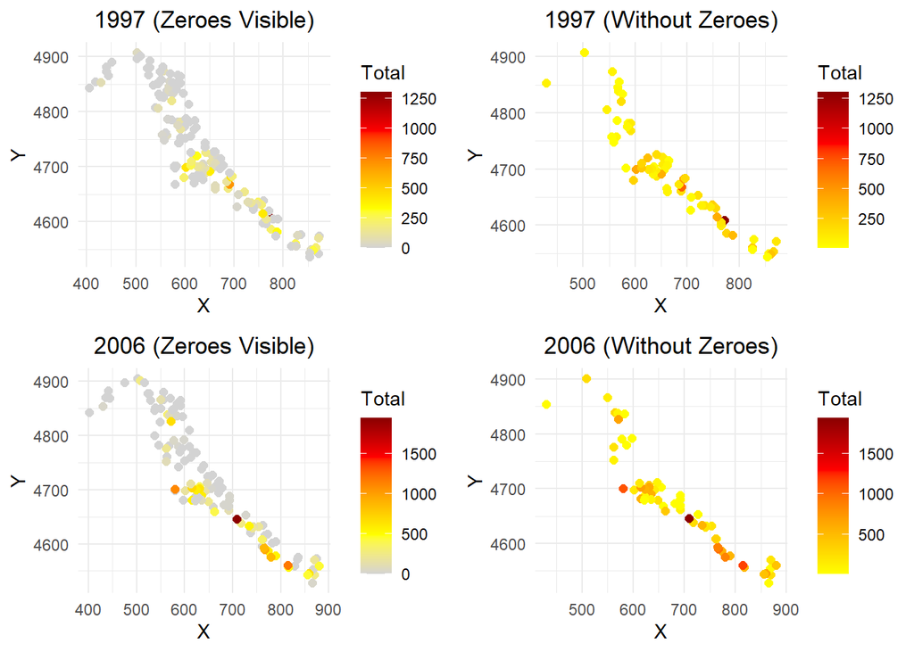

```r
shrimpsdata97 <- shrimpsdata %>% filter(ANNO == 1997)
shrimpsdata06 <- shrimpsdata %>% filter(ANNO == 2006)

color_with_zero <- c("lightgrey", "yellow", "orange", "red", "darkred")

map_1997_with_zero <- ggplot(shrimpsdata97, aes(x = X, y = Y)) +
  geom_point(aes(color = tot), size = 2) +
  scale_color_gradientn(colors = color_with_zero, limits = c(0, max(shrimpsdata97$tot)), na.value = "white") +
  labs(title = "1997 (Zeroes Visible)", color = "Total") +
  theme_minimal() +
  theme(plot.title = element_text(hjust = 0.5))

map_1997_no_zero <- ggplot(shrimpsdata97 %>% filter(tot > 0), aes(x = X, y = Y)) +
  geom_point(aes(color = tot), size = 2) +
  scale_color_gradientn(colors = color_with_zero[-1], limits = c(min(shrimpsdata97$tot[shrimpsdata97$tot > 0]), max(shrimpsdata97$tot)), na.value = "white") +
  labs(title = "1997 (Without Zeroes)", color = "Total") +
  theme_minimal() +
  theme(plot.title = element_text(hjust = 0.5))

map_2006_with_zero <- ggplot(shrimpsdata06, aes(x = X, y = Y)) +
  geom_point(aes(color = tot), size = 2) +
  scale_color_gradientn(colors = color_with_zero, limits = c(0, max(shrimpsdata06$tot)), na.value = "white") +
  labs(title = "2006 (Zeroes Visible)", color = "Total") +
  theme_minimal() +
  theme(plot.title = element_text(hjust = 0.5))

map_2006_no_zero <- ggplot(shrimpsdata06 %>% filter(tot > 0), aes(x = X, y = Y)) +
  geom_point(aes(color = tot), size = 2) +
  scale_color_gradientn(colors = color_with_zero[-1], limits = c(min(shrimpsdata06$tot[shrimpsdata06$tot > 0]), max(shrimpsdata06$tot)), na.value = "white") +
  labs(title = "2006 (Without Zeroes)", color = "Total") +
  theme_minimal() +
  theme(plot.title = element_text(hjust = 0.5))

grid.arrange(map_1997_with_zero, map_1997_no_zero, map_2006_with_zero, map_2006_no_zero, ncol = 2)
```

The maps above are useful to identify the maximal distance which will be used for kriging.

# Year 1997 :

## PCA

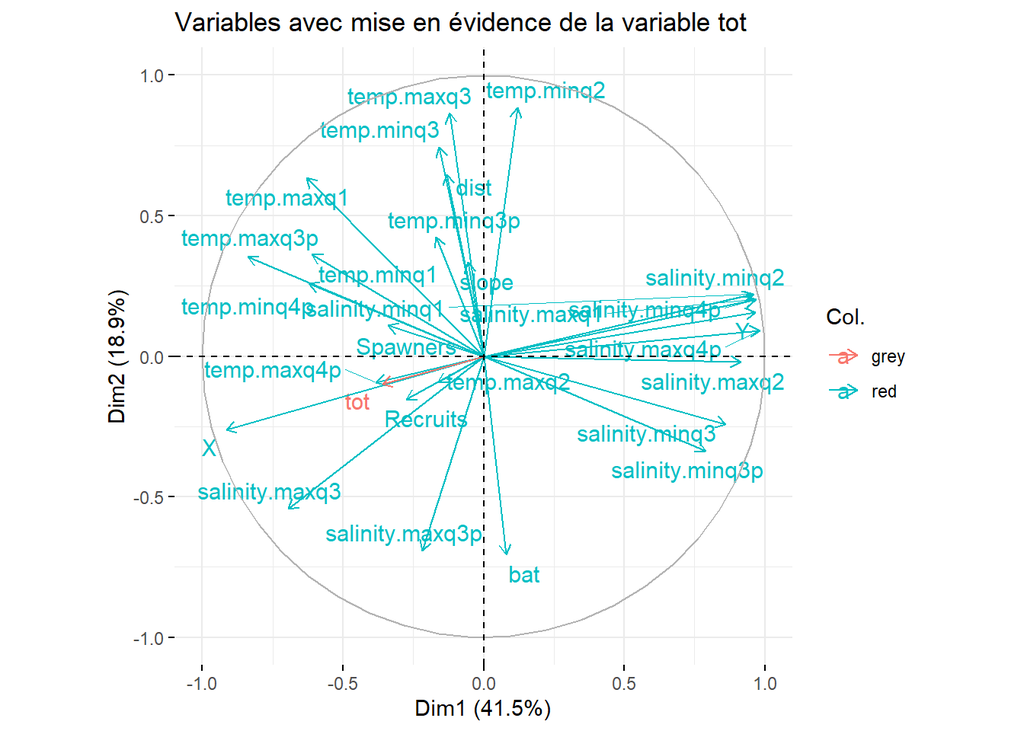

```r
shrimpsdata97_acp <- shrimpsdata97[, sapply(shrimpsdata97, is.numeric)]
shrimpsdata97_acp <- shrimpsdata97_acp[ , !names(shrimpsdata97_acp) %in% c("ANNO")]

acp_result <- PCA(shrimpsdata97_acp, graph = FALSE)

fviz_pca_var(acp_result,
             col.var = ifelse(rownames(acp_result$var$coord) == "tot", "grey", "red"),
             repel = TRUE,
             title = "Variables avec mise en évidence de la variable tot")
```

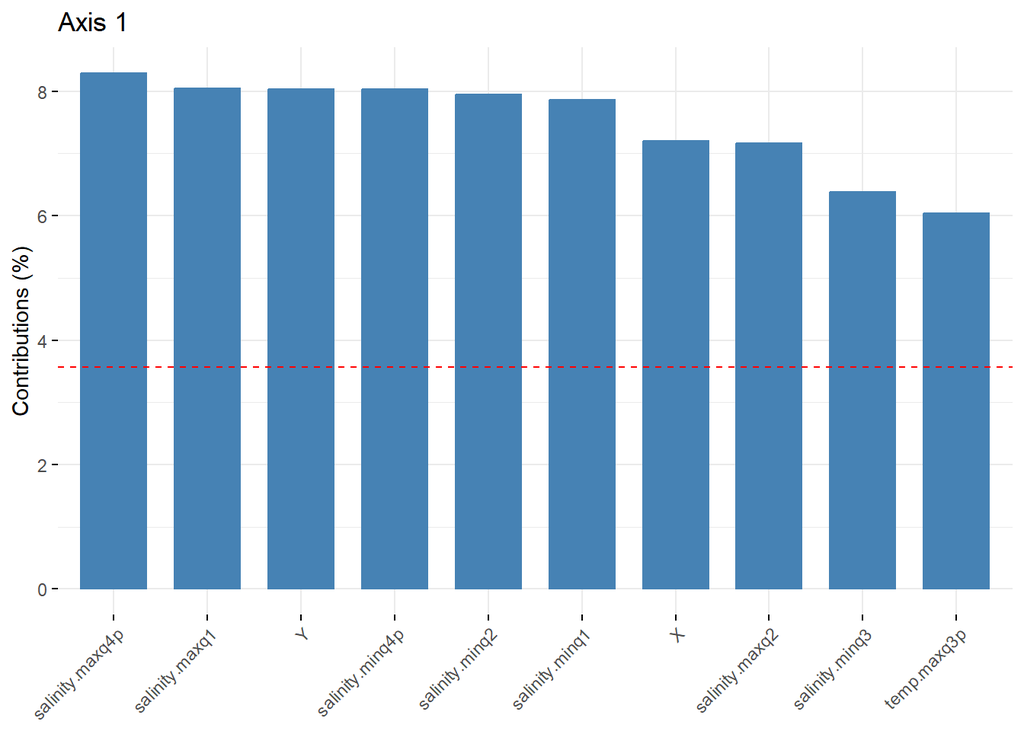

```r
fviz_contrib(acp_result, choice = "var", axes = 1, top = 10, title = "Axis 1")
```

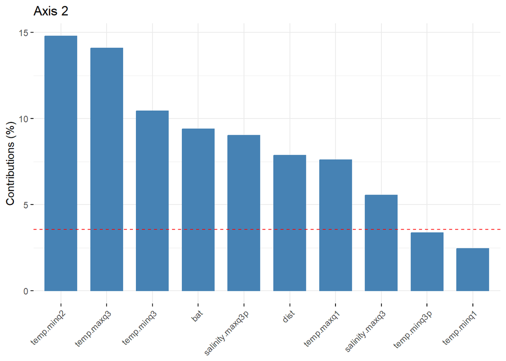

```r
fviz_contrib(acp_result, choice = "var", axes = 2, top = 10, title = "Axis 2")
```

## Correlation

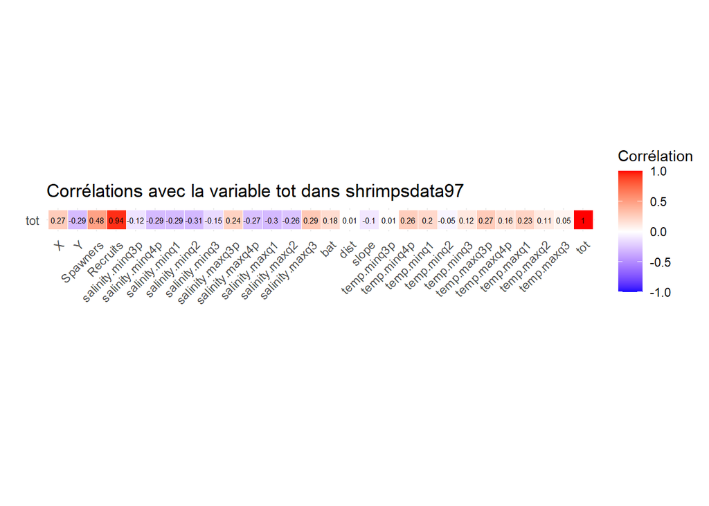

```r
correlation_matrix97 <- cor(shrimpsdata97)
correlation_matrix_melted97 <- melt(correlation_matrix97)
correlation_matrix_tot97 <- correlation_matrix_melted97 %>%
  filter(Var1 == "tot" & Var2 != "ANNO")

# Créer une heatmap pour la ligne de la variable "tot"
ggplot(data = correlation_matrix_tot97, aes(x = Var2, y = Var1, fill = value)) +
  geom_tile(color = "white") +
  geom_text(aes(label = round(value, 2)), color = "black", size = 2) +  # Afficher les coefficients arrondis
  scale_fill_gradient2(low = "blue", high = "red", mid = "white", midpoint = 0, limit = c(-1, 1), space = "Lab",
                       name = "Corrélation") +
  theme_minimal() +
  theme(axis.text.x = element_text(angle = 45, vjust = 1, hjust = 1)) +
  labs(title = "Corrélations avec la variable tot dans shrimpsdata97", x = "", y = "") +
  coord_fixed()
```

## Variogram

```r
coords97 <- shrimpsdataframe97 %>% select(X, Y)
shrimps_geor97 <- as.geodata(shrimpsdataframe97,
                             coords.col = 1:2,
                             data.col = which(names(shrimpsdataframe97) == "tot"),
                             covar.col = which(names(shrimpsdataframe97) %in% c("bat", "tempmax3p", "temp.maxq1", "temp.minq4p", "temp.maxq3p", "salinity.maxq3p", "salinity.maxq3")))

vv <- variog(shrimps_geor97)
```

```
## variog: computing omnidirectional variogram
```

```r
summary(vv)
```

```
##                  Length Class  Mode
## u                13     -none- numeric
## v                13     -none- numeric
## n                13     -none- numeric
## sd               13     -none- numeric
## bins.lim         14     -none- numeric
## ind.bin          13     -none- logical
## var.mark          1     -none- numeric
## beta.ols          1     -none- numeric
## output.type       1     -none- character
## max.dist          1     -none- numeric
## estimator.type    1     -none- character
## n.data            1     -none- numeric
## lambda            1     -none- numeric
## trend             1     -none- character
## pairs.min         1     -none- numeric
## nugget.tolerance  1     -none- numeric
## direction         1     -none- character
## tolerance         1     -none- character
## uvec             13     -none- numeric
## call              2     -none- call
```

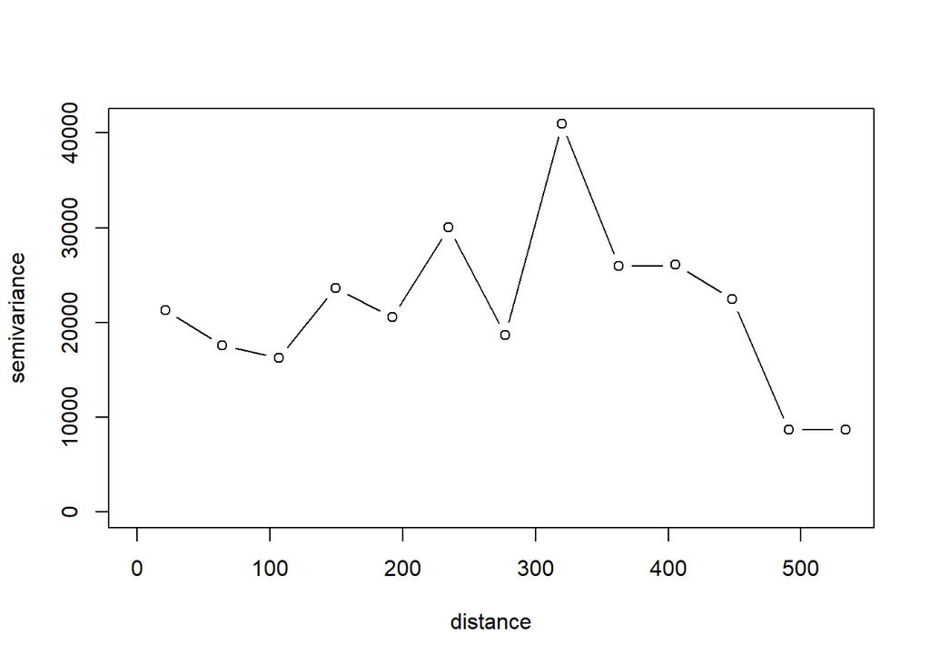

```r
plot(vv,type="b")
```

```r
vv1 <- variog(shrimps_geor97, trend = "1st", max.dist = 60, lambda = 0)
```

```
## variog: computing omnidirectional variogram
```

```r
vv2 <- variog(shrimps_geor97, trend = ~ bat + temp.maxq1 + temp.minq4p + temp.maxq3p + salinity.maxq3p + salinity.maxq3, max.dist = 60, lambda = 0)
```

```
## variog: computing omnidirectional variogram
```

```r
vv3 <- variog(shrimps_geor97, trend = ~ temp.maxq1 + temp.minq4p + temp.maxq3p + salinity.maxq3p + salinity.maxq3, max.dist = 60, lambda = 0)
```

```
## variog: computing omnidirectional variogram
```

```r
vv4 <- variog(shrimps_geor97, trend = ~ salinity.maxq3p + salinity.maxq3, max.dist = 60, lambda = 0)
```

```
## variog: computing omnidirectional variogram
```

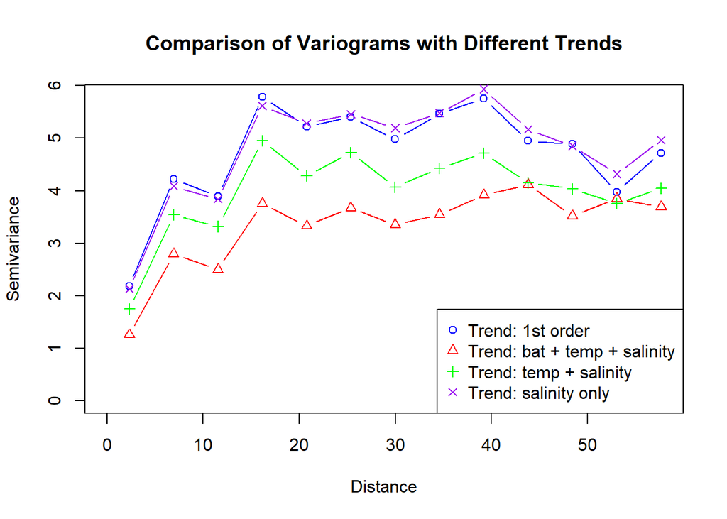

```r
plot(vv1, type = "b", col = "blue", xlab = "Distance", ylab = "Semivariance", main = "Comparison of Variograms with Different Trends")
lines(vv2$u, vv2$v, type = "b", col = "red", pch = 2)
lines(vv3$u, vv3$v, type = "b", col = "green", pch = 3)
lines(vv4$u, vv4$v, type = "b", col = "purple", pch = 4)


legend("bottomright", legend = c("Trend: 1st order", "Trend: bat + temp + salinity", "Trend: temp + salinity", "Trend: salinity only"),
       col = c("blue", "red", "green", "purple"), pch = c(1, 2, 3, 4))
```

We pick the most complex option as it seems to reach the top and level off unlike others. It looks stationary

```r
vv <- variog(shrimps_geor97, trend = ~ bat + temp.maxq1 + temp.minq4p + temp.maxq3p + salinity.maxq3p + salinity.maxq3, max.dist = 60, lambda = 0)
```

```
## variog: computing omnidirectional variogram
```

```r
plot(vv, type = "b")

vv.exp <- likfit(shrimps_geor97, trend = ~ bat + temp.maxq1 + temp.minq4p + temp.maxq3p + salinity.maxq3p + salinity.maxq3,
                 cov.model = "exponential", ini.cov.pars = c(2000, 60), lambda = 0, nugget = 1)
```

```
## kappa not used for the exponential correlation function
## ---------------------------------------------------------------
## likfit: likelihood maximisation using the function optim.
## likfit: Use control() to pass additional
##          arguments for the maximisation function.
##         For further details see documentation for optim.
## likfit: It is highly advisable to run this function several
##         times with different initial values for the parameters.
## likfit: WARNING: This step can be time demanding!
## ---------------------------------------------------------------
## likfit: end of numerical maximisation.
```

```r
lines.variomodel(vv.exp, col = "red")

vv.sph <- likfit(shrimps_geor97, trend = ~ bat + temp.maxq1 + temp.minq4p + temp.maxq3p + salinity.maxq3p + salinity.maxq3,
                 cov.model = "spherical", ini.cov.pars = c(2000, 60), lambda = 0, nugget = 1)
```

```
## kappa not used for the spherical correlation function
## ---------------------------------------------------------------
## likfit: likelihood maximisation using the function optim.
## likfit: Use control() to pass additional
##          arguments for the maximisation function.
##         For further details see documentation for optim.
## likfit: It is highly advisable to run this function several
##         times with different initial values for the parameters.
## likfit: WARNING: This step can be time demanding!
## ---------------------------------------------------------------
## likfit: end of numerical maximisation.
```

```r
lines.variomodel(vv.sph, col = "blue")

vv.gau <- likfit(shrimps_geor97, trend = ~ bat + temp.maxq1 + temp.minq4p + temp.maxq3p + salinity.maxq3p + salinity.maxq3,
                 cov.model = "gaussian", ini.cov.pars = c(2000, 60), lambda = 0, nugget = 1)
```

```
## kappa not used for the gaussian correlation function
## ---------------------------------------------------------------
## likfit: likelihood maximisation using the function optim.
## likfit: Use control() to pass additional
##          arguments for the maximisation function.
##         For further details see documentation for optim.
## likfit: It is highly advisable to run this function several
##         times with different initial values for the parameters.
## likfit: WARNING: This step can be time demanding!
## ---------------------------------------------------------------
## likfit: end of numerical maximisation.
```

```r
lines.variomodel(vv.gau, col = "green")

vv.matern1 <- likfit(shrimps_geor97, trend = ~ bat + temp.maxq1 + temp.minq4p + temp.maxq3p + salinity.maxq3p + salinity.maxq3,
                    cov.model = "matern", ini.cov.pars = c(2000, 60), lambda = 0, nugget = 1, kappa = 0.3)
```

```
## ---------------------------------------------------------------
## likfit: likelihood maximisation using the function optim.
## likfit: Use control() to pass additional
##          arguments for the maximisation function.
##         For further details see documentation for optim.
## likfit: It is highly advisable to run this function several
##         times with different initial values for the parameters.
## likfit: WARNING: This step can be time demanding!
## ---------------------------------------------------------------
## likfit: end of numerical maximisation.
```

```r
lines.variomodel(vv.matern1, col = "purple")

vv.matern2 <- likfit(shrimps_geor97, trend = ~ bat + temp.maxq1 + temp.minq4p + temp.maxq3p + salinity.maxq3p + salinity.maxq3,
                    cov.model = "matern", ini.cov.pars = c(2000, 60), lambda = 0, nugget = 1, kappa = 1.2) #
```

```
## ---------------------------------------------------------------
## likfit: likelihood maximisation using the function optim.
## likfit: Use control() to pass additional
##          arguments for the maximisation function.
##         For further details see documentation for optim.
## likfit: It is highly advisable to run this function several
##         times with different initial values for the parameters.
## likfit: WARNING: This step can be time demanding!
## ---------------------------------------------------------------
## likfit: end of numerical maximisation.
```

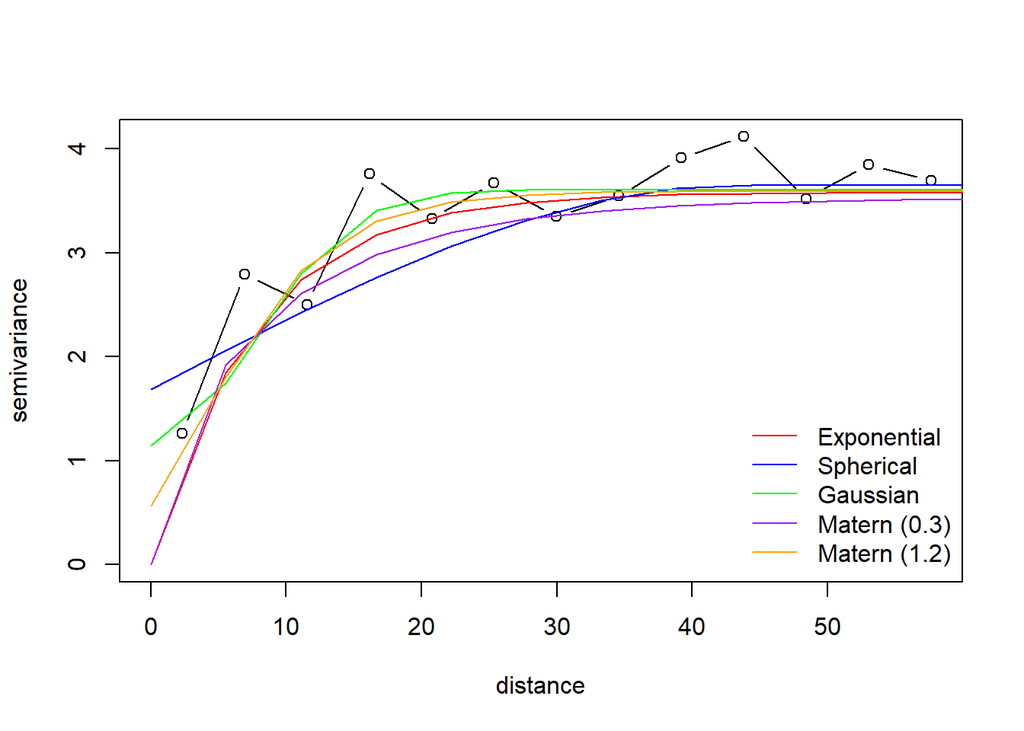

```r
lines.variomodel(vv.matern2, col = "orange")

legend("bottomright", legend = c("Exponential", "Spherical", "Gaussian", "Matern (0.3)", "Matern (1.2)"),
       col = c("red", "blue", "green", "purple", "orange"), lty = 1, bty = "n")
```

As it was dicussed in the previous homework, Gaussian and Matern (for certain kappas) have a curve at the beginning. This may contradict the perceived shape of the variogram, however if the curve is small and the overall fir is good Gaussian can still perform well. In any case, we have other models and its good to have Gaussian just for comparison.

```r
summary_exp <- summary(vv.exp)
summary_sph <- summary(vv.sph)
summary_gau <- summary(vv.gau)
summary_matern1 <- summary(vv.matern1)
summary_matern2 <- summary(vv.matern2)

loglik_exp <- summary_exp$likelihood$log.L
aic_exp <- summary_exp$likelihood$AIC
bic_exp <- summary_exp$likelihood$BIC

loglik_sph <- summary_sph$likelihood$log.L
aic_sph <- summary_sph$likelihood$AIC
bic_sph <- summary_sph$likelihood$BIC

loglik_gau <- summary_gau$likelihood$log.L
aic_gau <- summary_gau$likelihood$AIC
bic_gau <- summary_gau$likelihood$BIC

loglik_matern1 <- summary_matern1$likelihood$log.L
aic_matern1 <- summary_matern1$likelihood$AIC
bic_matern1 <- summary_matern1$likelihood$BIC

loglik_matern2 <- summary_matern2$likelihood$log.L
aic_matern2 <- summary_matern2$likelihood$AIC
bic_matern2 <- summary_matern2$likelihood$BIC

cv_exp <- mean(cv.exp$std.error^2)
cv_sph <- mean(cv.sph$std.error^2)
cv_gau <- mean(cv.gau$std.error^2)
cv_matern1 <- mean(cv.matern1$std.error^2)
cv_matern2 <- mean(cv.matern2$std.error^2)

model_comparison <- data.frame(
  Model = c("Exponential", "Spherical", "Gaussian", "Matern (0.3)", "Matern (1.2)"),
  LogLikelihood = c(loglik_exp, loglik_sph, loglik_gau, loglik_matern1, loglik_matern2),
  AIC = c(aic_exp, aic_sph, aic_gau, aic_matern1, aic_matern2),
  BIC = c(bic_exp, bic_sph, bic_gau, bic_matern1, bic_matern2),
  CrossValidationError = c(cv_exp, cv_sph, cv_gau, cv_matern1, cv_matern2)
)

print(model_comparison)
```

[output not shown]

```
##          Model LogLikelihood      AIC      BIC CrossValidationError
## 1  Exponential     -596.7309 1213.462 1243.766            0.3299268
## 2    Spherical     -598.5744 1217.149 1247.453            0.3128182
## 3     Gaussian     -598.1936 1216.387 1246.692            0.3369436
## 4 Matern (0.3)     -597.0639 1214.128 1244.432            0.2928622
## 5 Matern (1.2)     -597.2935 1214.587 1244.891            0.3306852
```

The models are all pretty close. As before, CV is the main criterion and it leads us to choose Matern with kappa = 0.3

```r
kriging_result <- krige.conv(
  geodata = shrimps_geor97,
  locations = grid_1997[, c("X", "Y")],
  krige = krige.control(
    obj.model = vv.matern1
  )
)
```

```
## krige.conv: model with constant mean
## krige.conv: performing the Box-Cox data transformation
## krige.conv: back-transforming the predicted mean and variance
## krige.conv: Kriging performed using global neighbourhood
```

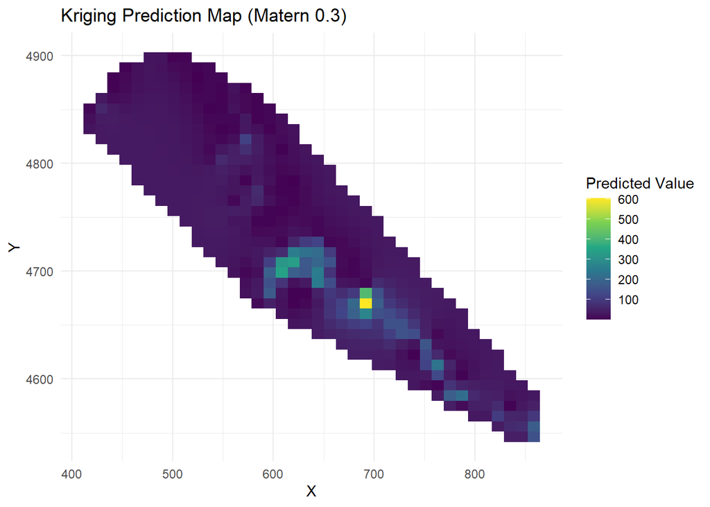

```r
predicted_grid <- cbind(
  grid_1997,
  Prediction = kriging_result$predict,
  Variance = kriging_result$krige.var,
  Lower_CI = kriging_result$predict - 1.96 * sqrt(kriging_result$krige.var),
  Upper_CI = kriging_result$predict + 1.96 * sqrt(kriging_result$krige.var)
)

ggplot(predicted_grid, aes(x = X, y = Y, fill = Prediction)) +
  geom_tile() +
  scale_fill_viridis_c() +
  labs(title = "Kriging Prediction Map (Matern 0.3)", fill = "Predicted Value") +
  theme_minimal()
```

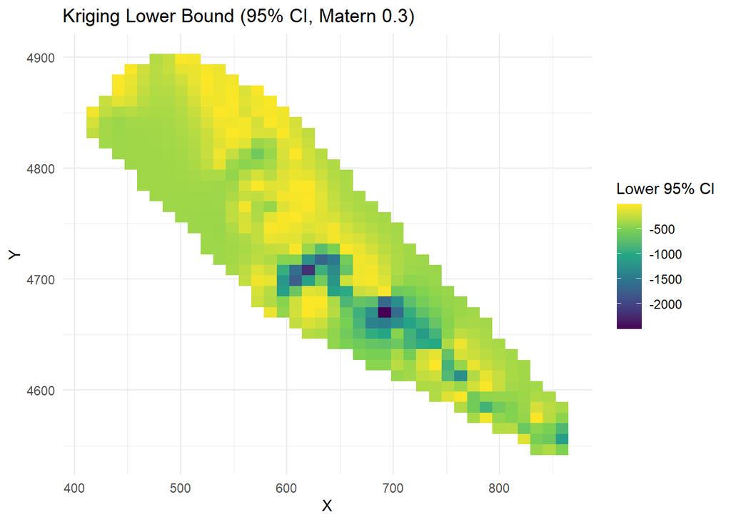

```r
ggplot(predicted_grid, aes(x = X, y = Y, fill = Lower_CI)) +
  geom_tile() +
  scale_fill_viridis_c() +
  labs(title = "Kriging Lower Bound (95% CI, Matern 0.3)", fill = "Lower 95% CI") +
  theme_minimal()
```

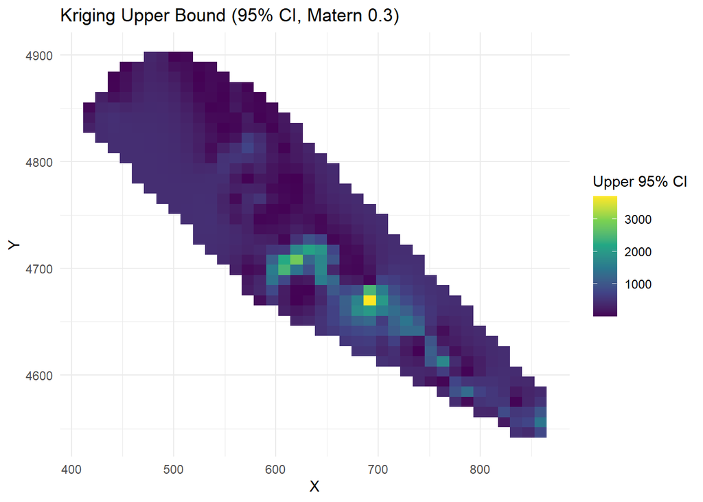

```r
ggplot(predicted_grid, aes(x = X, y = Y, fill = Upper_CI)) +
  geom_tile() +
  scale_fill_viridis_c() +
  labs(title = "Kriging Upper Bound (95% CI, Matern 0.3)", fill = "Upper 95% CI") +
  theme_minimal()
```

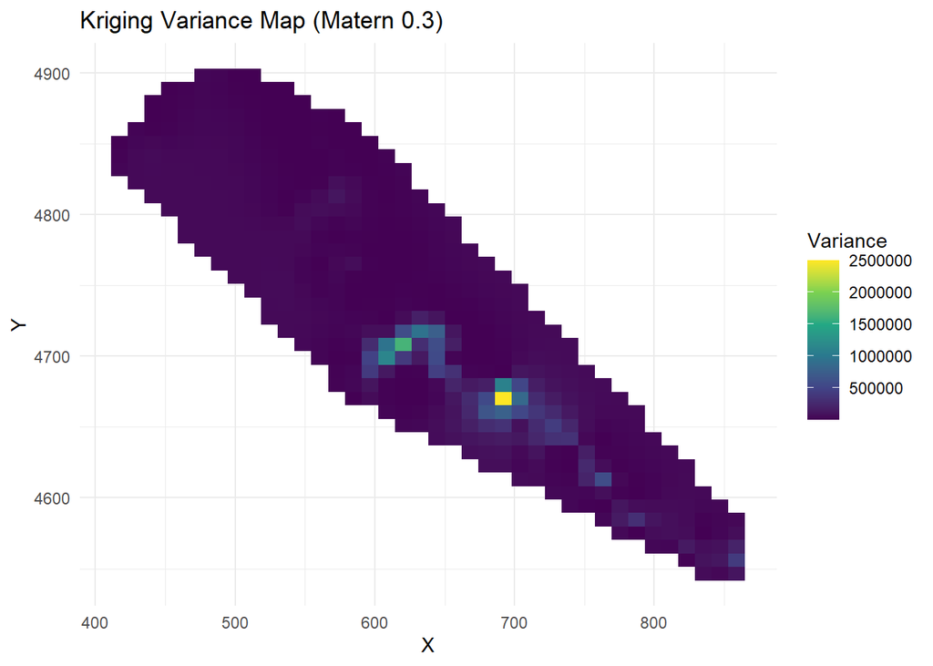

```r
ggplot(predicted_grid, aes(x = X, y = Y, fill = Variance)) +
  geom_tile() +
  scale_fill_viridis_c() +
  labs(title = "Kriging Variance Map (Matern 0.3)", fill = "Variance") +
  theme_minimal()
```

It should be noted that biomass, of course, cannot be negative. So, techically we could set all negative values for the lower bound to 0, but then the whole grid would look the same (0s everywhere). This issue is most likely due to large variance.

# Year 2006 :

## PCA

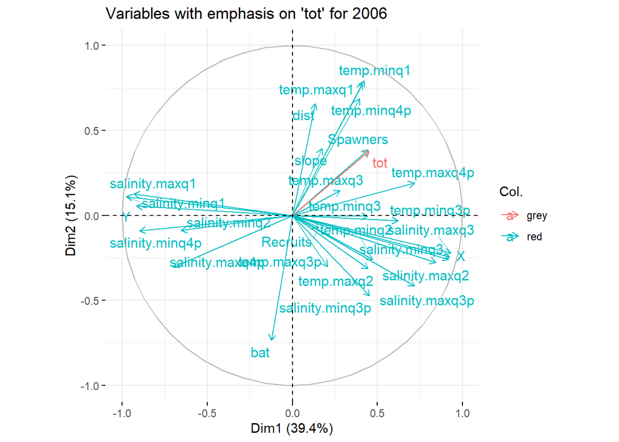

```r
shrimpsdata06_acp <- shrimpsdata06 %>%
    select(where(is.numeric)) %>%
    select(-matches("ANNO"))  # Exclude the year column if present

acp_result_2006 <- PCA(shrimpsdata06_acp, graph = FALSE)

fviz_pca_var(acp_result_2006,
    col.var = ifelse(rownames(acp_result_2006$var$coord) == "tot", "grey", "red"),
    repel = TRUE,
    title = "Variables with emphasis on 'tot' for 2006"
)
```

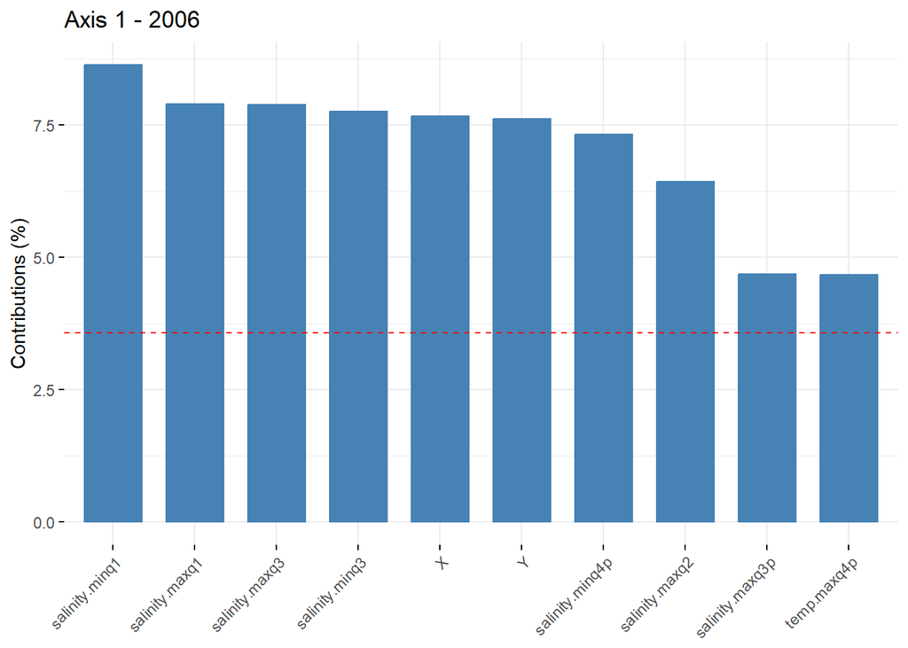

```r
fviz_contrib(acp_result_2006, choice = "var", axes = 1, top = 10, title = "Axis 1 - 2006")
```

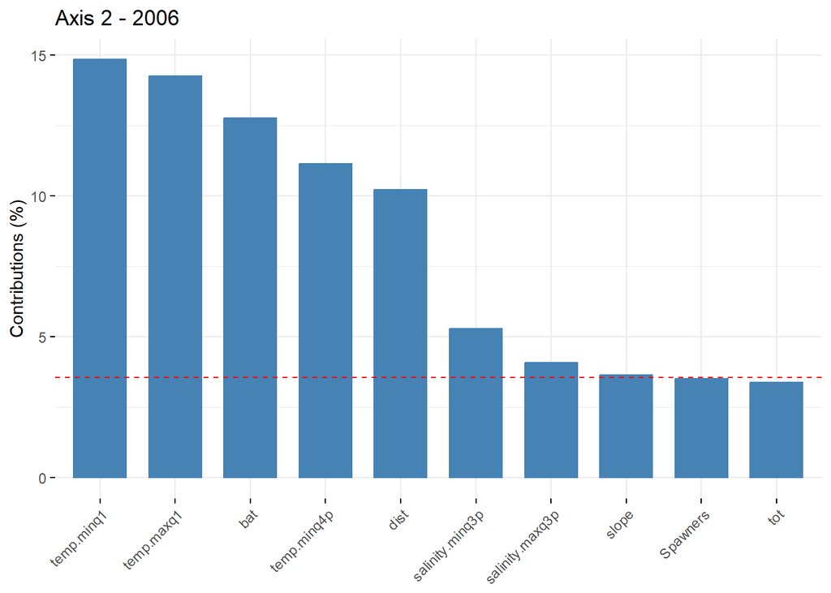

```r
fviz_contrib(acp_result_2006, choice = "var", axes = 2, top = 10, title = "Axis 2 - 2006")
```

## Correlation

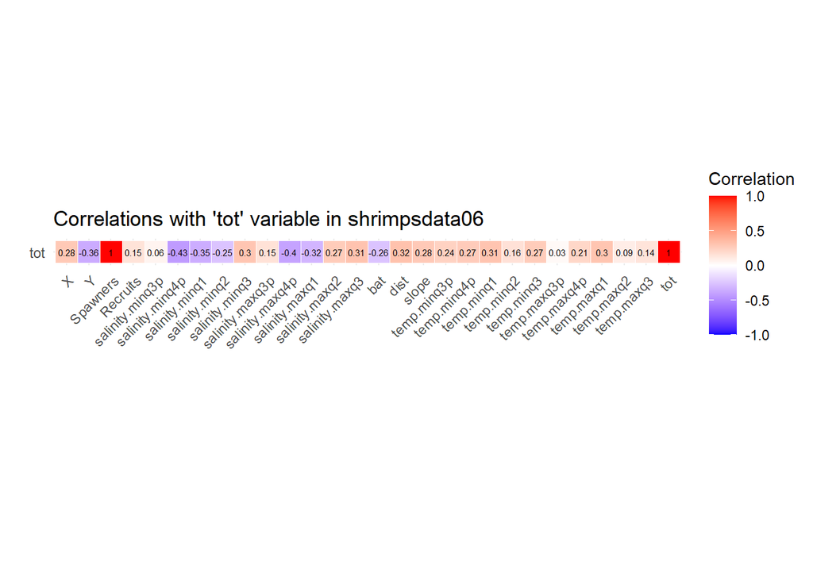

```r
correlation_matrix06 <- cor(shrimpsdata06)
correlation_matrix_melted06 <- melt(correlation_matrix06)
correlation_matrix_tot06 <- correlation_matrix_melted06 %>%
    filter(Var1 == "tot" & Var2 != "ANNO")

ggplot(data = correlation_matrix_tot06, aes(x = Var2, y = Var1, fill = value)) +
    geom_tile(color = "white") +
    geom_text(aes(label = round(value, 2)), color = "black", size = 2) +
    scale_fill_gradient2(low = "blue", high = "red", mid = "white", midpoint = 0, limit = c(-1, 1), space = "Lab",
                         name = "Correlation") +
    theme_minimal() +
    theme(axis.text.x = element_text(angle = 45, vjust = 1, hjust = 1)) +
    labs(title = "Correlations with 'tot' variable in shrimpsdata06", x = "", y = "") +
    coord_fixed()
```

```r
coords06 <- shrimpsdataframe06 %>% select(X, Y)
shrimps_geor06 <- as.geodata(shrimpsdataframe06,
                             coords.col = 1:2,
                             data.col = which(names(shrimpsdataframe06) == "tot"),
                             covar.col = which(names(shrimpsdataframe06) %in% c("bat", "tempmax3p", "temp.maxq1", "temp.minq4p", "temp.maxq3p", "salinity.maxq3p", "salinity.maxq3")))

vv <- variog(shrimps_geor06)
```

```
## variog: computing omnidirectional variogram
```

```r
summary(vv)
```

```
##                  Length Class  Mode
## u                13     -none- numeric
## v                13     -none- numeric
## n                13     -none- numeric
## sd               13     -none- numeric
## bins.lim         14     -none- numeric
## ind.bin          13     -none- logical
## var.mark          1     -none- numeric
## beta.ols          1     -none- numeric
## output.type       1     -none- character
## max.dist          1     -none- numeric
## estimator.type    1     -none- character
## n.data            1     -none- numeric
## lambda            1     -none- numeric
## trend             1     -none- character
## pairs.min         1     -none- numeric
## nugget.tolerance  1     -none- numeric
## direction         1     -none- character
## tolerance         1     -none- character
## uvec             13     -none- numeric
## call              2     -none- call
```

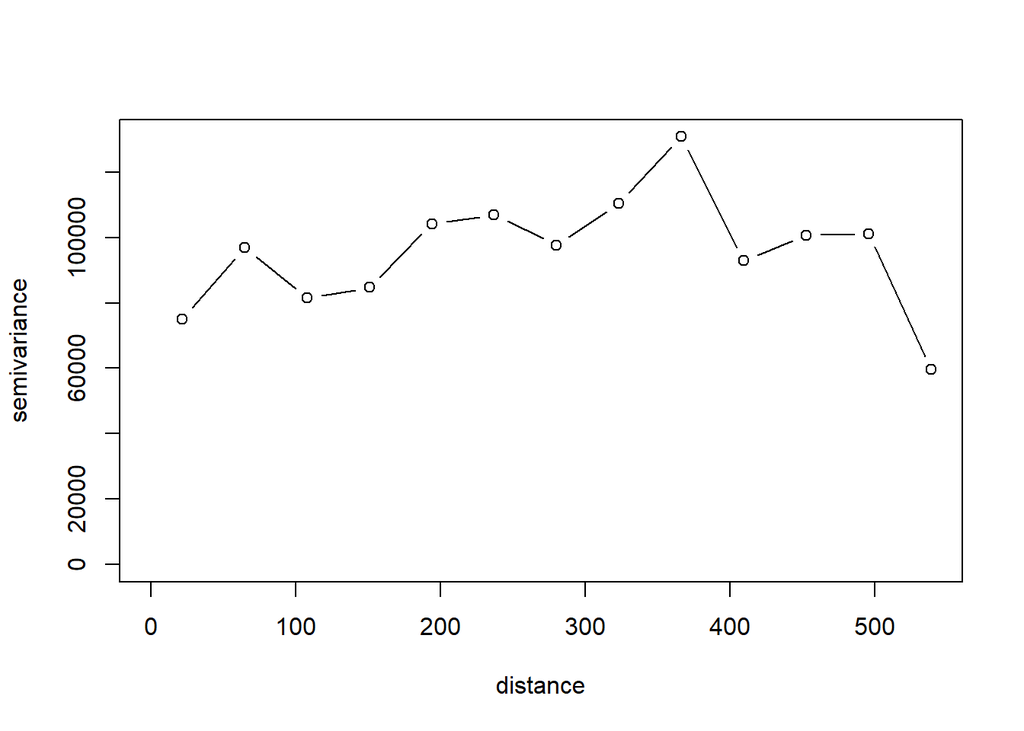

```r
plot(vv,type="b")
```

```r
vv1 <- variog(shrimps_geor06, trend = "1st", max.dist = 60, lambda = 0)
```

```
## variog: computing omnidirectional variogram
```

```r
vv2 <- variog(shrimps_geor06, trend = ~ bat + temp.maxq1 + temp.minq4p + temp.maxq3p + salinity.maxq3p + salinity.maxq3, max.dist = 60, lambda = 0)
```

```
## variog: computing omnidirectional variogram
```

```r
vv3 <- variog(shrimps_geor06, trend = ~ temp.maxq1 + temp.minq4p + temp.maxq3p + salinity.maxq3p + salinity.maxq3, max.dist = 60, lambda = 0)
```

```
## variog: computing omnidirectional variogram
```

```r
vv4 <- variog(shrimps_geor06, trend = ~ salinity.maxq3p + salinity.maxq3, max.dist = 60, lambda = 0)
```

```
## variog: computing omnidirectional variogram
```

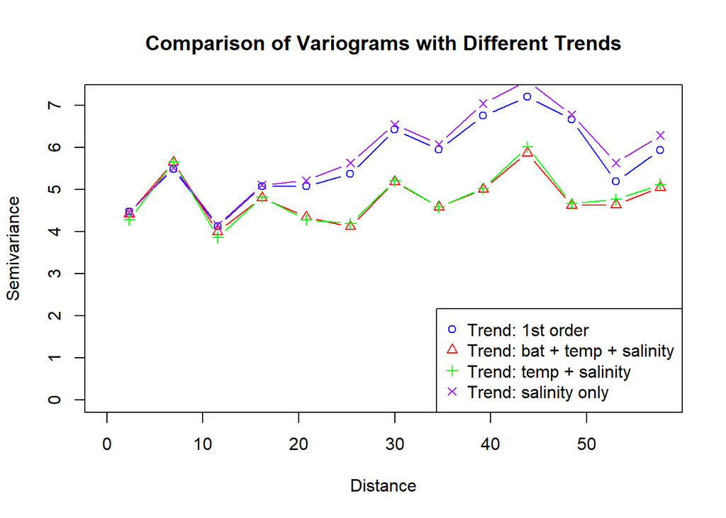

```r
plot(vv1, type = "b", col = "blue", xlab = "Distance", ylab = "Semivariance", main = "Comparison of Variograms with Different Trends")
lines(vv2$u, vv2$v, type = "b", col = "red", pch = 2)
lines(vv3$u, vv3$v, type = "b", col = "green", pch = 3)
lines(vv4$u, vv4$v, type = "b", col = "purple", pch = 4)

legend("bottomright", legend = c("Trend: 1st order", "Trend: bat + temp + salinity", "Trend: temp + salinity", "Trend: salinity only"),
       col = c("blue", "red", "green", "purple"), pch = c(1, 2, 3, 4))
```

```r
vv <- variog(shrimps_geor06, trend = ~ bat + temp.maxq1 + temp.minq4p + temp.maxq3p + salinity.maxq3, max.dist = 60, lambda = 0)
```

```
## variog: computing omnidirectional variogram
```

```r
plot(vv, type = "b")

vv.exp <- likfit(shrimps_geor06, trend = ~ bat + temp.maxq1 + temp.minq4p + temp.maxq3p + salinity.maxq3,
                 cov.model = "exponential", ini.cov.pars = c(2000, 60), lambda = 0, nugget = 1)
```

```
## kappa not used for the exponential correlation function
## ---------------------------------------------------------------
## likfit: likelihood maximisation using the function optim.
## likfit: Use control() to pass additional
##          arguments for the maximisation function.
##         For further details see documentation for optim.
## likfit: It is highly advisable to run this function several
##         times with different initial values for the parameters.
## likfit: WARNING: This step can be time demanding!
## ---------------------------------------------------------------
## likfit: end of numerical maximisation.
```

```r
lines.variomodel(vv.exp, col = "red")

vv.sph <- likfit(shrimps_geor06, trend = ~ bat + temp.maxq1 + temp.minq4p + temp.maxq3p + salinity.maxq3,
                 cov.model = "spherical", ini.cov.pars = c(2000, 60), lambda = 0, nugget = 1)
```

```
## kappa not used for the spherical correlation function
## ---------------------------------------------------------------
## likfit: likelihood maximisation using the function optim.
## likfit: Use control() to pass additional
##          arguments for the maximisation function.
##         For further details see documentation for optim.
## likfit: It is highly advisable to run this function several
##         times with different initial values for the parameters.
## likfit: WARNING: This step can be time demanding!
## ---------------------------------------------------------------
## likfit: end of numerical maximisation.
```

```r
lines.variomodel(vv.sph, col = "blue")

vv.gau <- likfit(shrimps_geor06, trend = ~ bat + temp.maxq1 + temp.minq4p + temp.maxq3p + salinity.maxq3,
                 cov.model = "gaussian", ini.cov.pars = c(2000, 60), lambda = 0, nugget = 1)
```

```
## kappa not used for the gaussian correlation function
## ---------------------------------------------------------------
## likfit: likelihood maximisation using the function optim.
## likfit: Use control() to pass additional
##          arguments for the maximisation function.
##         For further details see documentation for optim.
## likfit: It is highly advisable to run this function several
##         times with different initial values for the parameters.
## likfit: WARNING: This step can be time demanding!
## ---------------------------------------------------------------
## likfit: end of numerical maximisation.
```

```r
lines.variomodel(vv.gau, col = "green")

vv.matern1 <- likfit(shrimps_geor06, trend = ~ bat + temp.maxq1 + temp.minq4p + temp.maxq3p + salinity.maxq3,
                     cov.model = "matern", ini.cov.pars = c(2000, 60), lambda = 0, nugget = 1, kappa = 0.3)
```

```
## ---------------------------------------------------------------
## likfit: likelihood maximisation using the function optim.
## likfit: Use control() to pass additional
##          arguments for the maximisation function.
##         For further details see documentation for optim.
## likfit: It is highly advisable to run this function several
##         times with different initial values for the parameters.
## likfit: WARNING: This step can be time demanding!
## ---------------------------------------------------------------
## likfit: end of numerical maximisation.
```

```r
lines.variomodel(vv.matern1, col = "purple")

vv.matern2 <- likfit(shrimps_geor06, trend = ~ bat + temp.maxq1 + temp.minq4p + temp.maxq3p + salinity.maxq3,
                     cov.model = "matern", ini.cov.pars = c(2000, 60), lambda = 0, nugget = 1, kappa = 1.1)
```

```
## ---------------------------------------------------------------
## likfit: likelihood maximisation using the function optim.
## likfit: Use control() to pass additional
##          arguments for the maximisation function.
##         For further details see documentation for optim.
## likfit: It is highly advisable to run this function several
##         times with different initial values for the parameters.
## likfit: WARNING: This step can be time demanding!
## ---------------------------------------------------------------
## likfit: end of numerical maximisation.
```

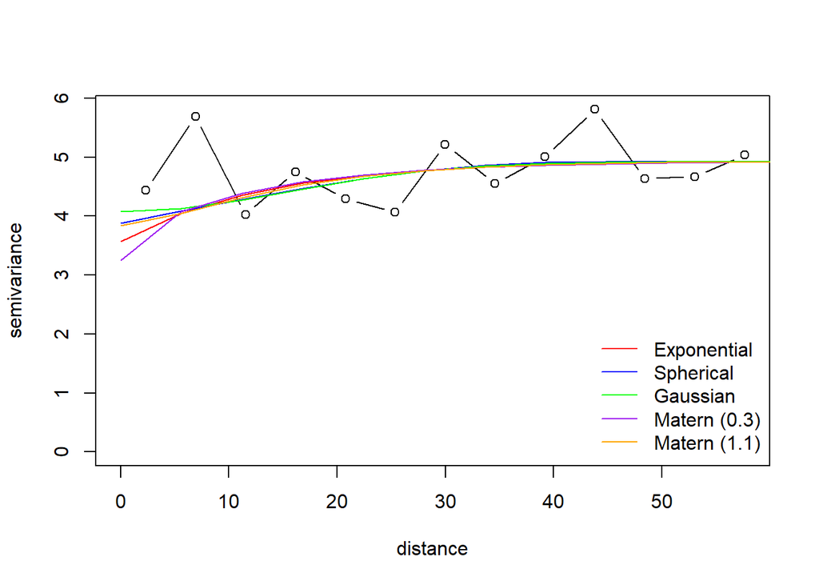

```r
lines.variomodel(vv.matern2, col = "orange")

legend("bottomright", legend = c("Exponential", "Spherical", "Gaussian", "Matern (0.3)", "Matern (1.1)"),
       col = c("red", "blue", "green", "purple", "orange"), lty = 1, bty = "n")
```

Here the variogram does not really look stationary. It is not terribly unstable but there is no cleare range and sill. Also, in this case the Gaussian shape can be justified.

```r
cv.exp <- xvalid(shrimps_geor06, model = vv.exp)
```

```
## xvalid: number of data locations       = 120
## xvalid: number of validation locations = 120
## xvalid: performing cross-validation at location ... 1, 2, 3, 4, 5, 6, 7, 8, 9, 10, 11, 12, 13, 14, 15, 16, 17, 18, 19, 20, 21, 22, 23, 24, 25, 26, 27, 28, 29, 30, 31, 32, 33, 34, 35, 36, 37, 38, 39, 40, 41, 42, 43, 44, 45, 46, 47, 48, 49, 50, 51, 52, 53, 54, 55, 56, 57, 58, 59, 60, 61, 62, 63, 64…
## xvalid: end of cross-validation
```

```r
cv.sph <- xvalid(shrimps_geor06, model = vv.sph)
```

```
## xvalid: number of data locations       = 120
## xvalid: number of validation locations = 120
## xvalid: performing cross-validation at location ... 1, 2, 3, 4, 5, 6, 7, 8, 9, 10, 11, 12, 13, 14, 15, 16, 17, 18, 19, 20, 21, 22, 23, 24, 25, 26, 27, 28, 29, 30, 31, 32, 33, 34, 35, 36, 37, 38, 39, 40, 41, 42, 43, 44, 45, 46, 47, 48, 49, 50, 51, 52, 53, 54, 55, 56, 57, 58, 59, 60, 61, 62, 63, 64…
## xvalid: end of cross-validation
```

```r
cv.gau <- xvalid(shrimps_geor06, model = vv.gau)
```

```
## xvalid: number of data locations       = 120
## xvalid: number of validation locations = 120
## xvalid: performing cross-validation at location ... 1, 2, 3, 4, 5, 6, 7, 8, 9, 10, 11, 12, 13, 14, 15, 16, 17, 18, 19, 20, 21, 22, 23, 24, 25, 26, 27, 28, 29, 30, 31, 32, 33, 34, 35, 36, 37, 38, 39, 40, 41, 42, 43, 44, 45, 46, 47, 48, 49, 50, 51, 52, 53, 54, 55, 56, 57, 58, 59, 60, 61, 62, 63, 64…
## xvalid: end of cross-validation
```

```r
cv.matern1 <- xvalid(shrimps_geor06, model = vv.matern1)
```

```
## xvalid: number of data locations       = 120
## xvalid: number of validation locations = 120
## xvalid: performing cross-validation at location ... 1, 2, 3, 4, 5, 6, 7, 8, 9, 10, 11, 12, 13, 14, 15, 16, 17, 18, 19, 20, 21, 22, 23, 24, 25, 26, 27, 28, 29, 30, 31, 32, 33, 34, 35, 36, 37, 38, 39, 40, 41, 42, 43, 44, 45, 46, 47, 48, 49, 50, 51, 52, 53, 54, 55, 56, 57, 58, 59, 60, 61, 62, 63, 64…
## xvalid: end of cross-validation
```

```r
cv.matern2 <- xvalid(shrimps_geor06, model = vv.matern2)
```

```
## xvalid: number of data locations       = 120
## xvalid: number of validation locations = 120
## xvalid: performing cross-validation at location ... 1, 2, 3, 4, 5, 6, 7, 8, 9, 10, 11, 12, 13, 14, 15, 16, 17, 18, 19, 20, 21, 22, 23, 24, 25, 26, 27, 28, 29, 30, 31, 32, 33, 34, 35, 36, 37, 38, 39, 40, 41, 42, 43, 44, 45, 46, 47, 48, 49, 50, 51, 52, 53, 54, 55, 56, 57, 58, 59, 60, 61, 62, 63, 64…
## xvalid: end of cross-validation
```

```r
error.exp <- mean(cv.exp$std.error^2)
error.sph <- mean(cv.sph$std.error^2)
error.gau <- mean(cv.gau$std.error^2)
error.matern1 <- mean(cv.matern1$std.error^2)
error.matern2 <- mean(cv.matern2$std.error^2)

summary_exp <- summary(vv.exp)
summary_sph <- summary(vv.sph)
summary_gau <- summary(vv.gau)
summary_matern1 <- summary(vv.matern1)
summary_matern2 <- summary(vv.matern2)

loglik_exp <- summary_exp$likelihood$log.L
aic_exp <- summary_exp$likelihood$AIC
bic_exp <- summary_exp$likelihood$BIC

loglik_sph <- summary_sph$likelihood$log.L
aic_sph <- summary_sph$likelihood$AIC
bic_sph <- summary_sph$likelihood$BIC

loglik_gau <- summary_gau$likelihood$log.L
aic_gau <- summary_gau$likelihood$AIC
bic_gau <- summary_gau$likelihood$BIC

loglik_matern1 <- summary_matern1$likelihood$log.L
aic_matern1 <- summary_matern1$likelihood$AIC
bic_matern1 <- summary_matern1$likelihood$BIC

loglik_matern2 <- summary_matern2$likelihood$log.L
aic_matern2 <- summary_matern2$likelihood$AIC
bic_matern2 <- summary_matern2$likelihood$BIC

model_comparison <- data.frame(
  Model = c("Exponential", "Spherical", "Gaussian", "Matern (0.3)", "Matern (1.1)"),
  LogLikelihood = c(loglik_exp, loglik_sph, loglik_gau, loglik_matern1, loglik_matern2),
  AIC = c(aic_exp, aic_sph, aic_gau, aic_matern1, aic_matern2),
  BIC = c(bic_exp, bic_sph, bic_gau, bic_matern1, bic_matern2),
  CrossValidationError = c(error.exp, error.sph, error.gau, error.matern1, error.matern2)
)

print(model_comparison)
```

```
##          Model LogLikelihood      AIC      BIC CrossValidationError
## 1  Exponential     -561.0496 1140.099 1165.187           0.03651308
## 2    Spherical     -560.8240 1139.648 1164.735           0.03478996
## 3     Gaussian     -560.8478 1139.696 1164.783           0.03276132
## 4 Matern (0.3)     -561.1217 1140.243 1165.331           0.03664852
## 5 Matern (1.1)     -560.9589 1139.918 1165.005           0.03563531
```

Here Gaussian yeild the best CV scores.

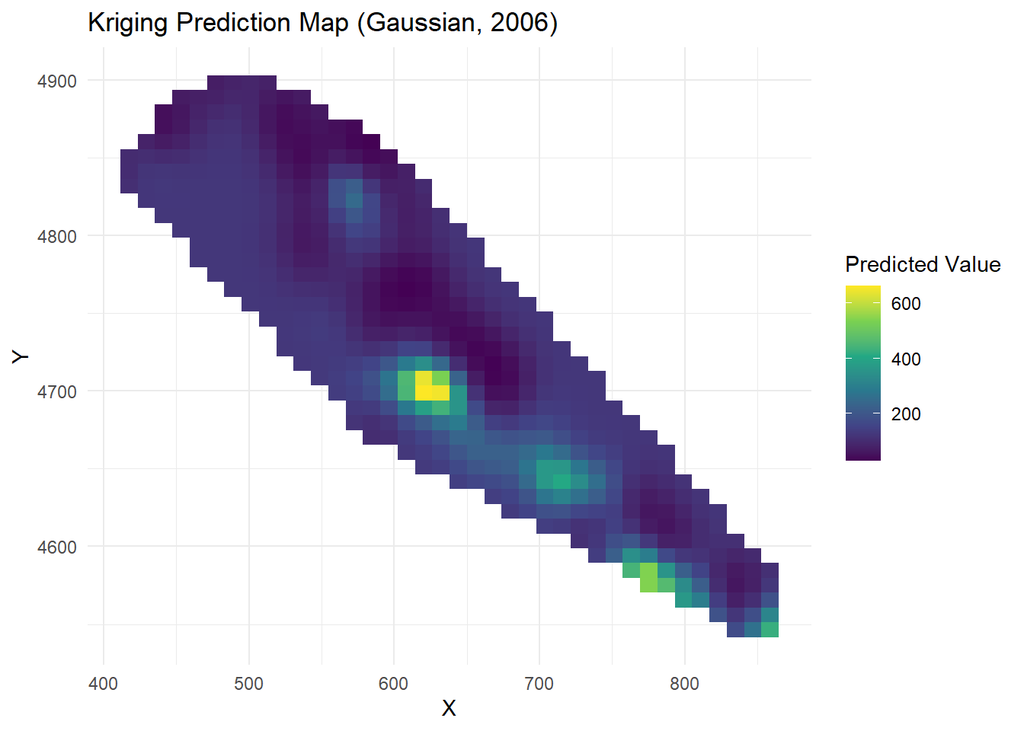

```r
predicted_grid <- cbind(
  grid_2006,
  Prediction = kriging_result$predict,
  Variance = kriging_result$krige.var,
  Lower_CI = kriging_result$predict - 1.96 * sqrt(kriging_result$krige.var),
  Upper_CI = kriging_result$predict + 1.96 * sqrt(kriging_result$krige.var)
)

ggplot(predicted_grid, aes(x = X, y = Y, fill = Prediction)) +
  geom_tile() +
  scale_fill_viridis_c() +
  labs(title = "Kriging Prediction Map (Gaussian, 2006)", fill = "Predicted Value") +
  theme_minimal()
```

[output not shown]

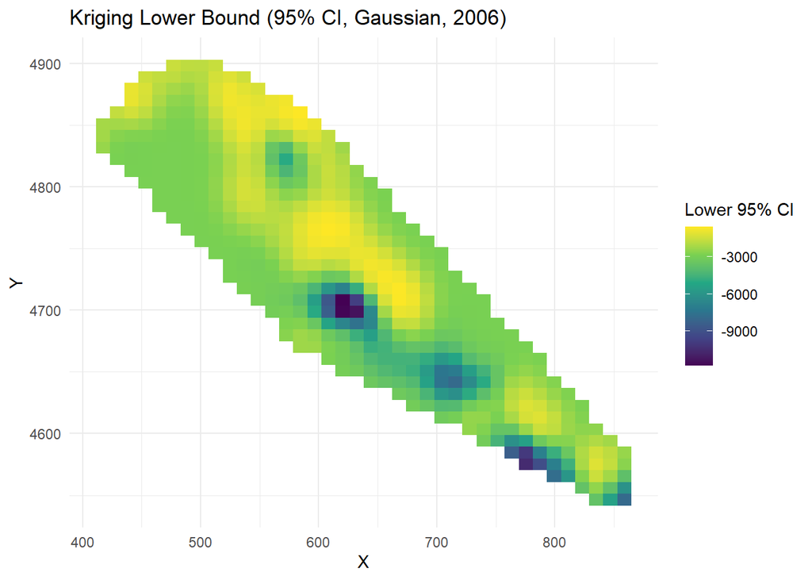

```r
ggplot(predicted_grid, aes(x = X, y = Y, fill = Lower_CI)) +
  geom_tile() +
  scale_fill_viridis_c() +
  labs(title = "Kriging Lower Bound (95% CI, Gaussian, 2006)", fill = "Lower 95% CI") +
  theme_minimal()
```

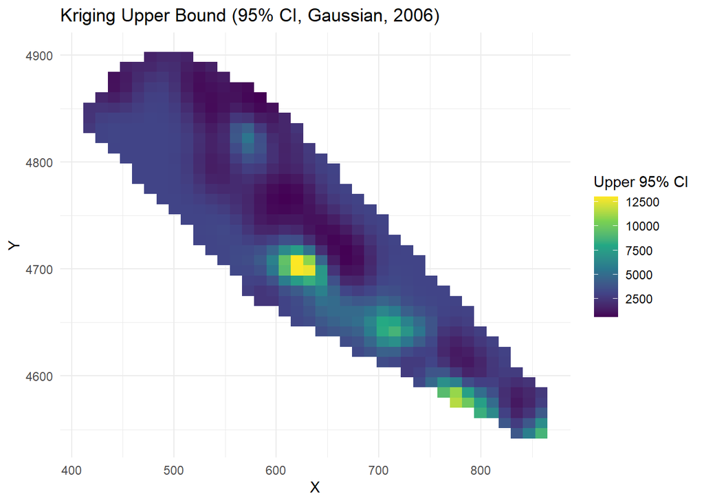

```r
ggplot(predicted_grid, aes(x = X, y = Y, fill = Upper_CI)) +
  geom_tile() +
  scale_fill_viridis_c() +
  labs(title = "Kriging Upper Bound (95% CI, Gaussian, 2006)", fill = "Upper 95% CI") +
  theme_minimal()
```

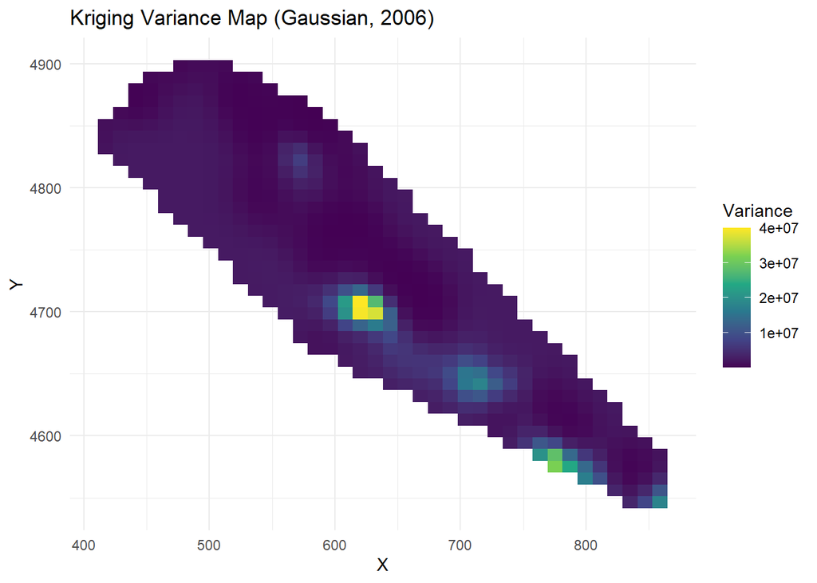

```r
ggplot(predicted_grid, aes(x = X, y = Y, fill = Variance)) +
  geom_tile() +
  scale_fill_viridis_c() +
  labs(title = "Kriging Variance Map (Gaussian, 2006)", fill = "Variance") +
  theme_minimal()
```

The same comment about variance. If we go back to original maps and values, obtained predictions for both years don’t seem off. However, the variance for both years is very large and 0 is in the confidence interval everywhere